# Part2 - ML Modelling of Parkinson's Disease Detection through Voice technique

# 1) Data Preparation

## 1.1) Import Python Libraries

```python
import numpy as np
import pandas as pd
import matplotlib.pyplot as plt
import seaborn as sns
import itertools
import datetime
from sklearn.preprocessing import StandardScaler,MinMaxScaler
from imblearn.over_sampling import SMOTE

from pycaret.classification import *
from pycaret.utils import version
from pycaret.utils import check_metric

import ipywidgets as widgets
from IPython.display import display, Markdown, Latex, clear_output
from tqdm import tqdm
```

## 1.2) Verify PyCaret Version

```python
### Check the Pycaret Version
display(f"PyCaret Version : {version()}")
```

```
'PyCaret Version : 2.2.0'
```

## 1.3) Read the data into a Pandas DataFrame

```python
df= pd.read_csv("Data - Parkinsons")
df.head()
```

|  | name | MDVP:Fo(Hz) | MDVP:Fhi(Hz) | MDVP:Flo(Hz) | MDVP:Jitter(%) | MDVP:Jitter(Abs) | MDVP:RAP | MDVP:PPQ | Jitter:DDP | MDVP:Shimmer | MDVP:Shimmer(dB) | Shimmer:APQ3 | Shimmer:APQ5 | MDVP:APQ | Shimmer:DDA | NHR | HNR | status | RPDE | DFA | spread1 | spread2 | D2 | PPE |
| --- | --- | --- | --- | --- | --- | --- | --- | --- | --- | --- | --- | --- | --- | --- | --- | --- | --- | --- | --- | --- | --- | --- | --- | --- |
| 0 | phon_R01_S01_1 | 119.992 | 157.302 | 74.997 | 0.00784 | 0.00007 | 0.00370 | 0.00554 | 0.01109 | 0.04374 | 0.426 | 0.02182 | 0.03130 | 0.02971 | 0.06545 | 0.02211 | 21.033 | 1 | 0.414783 | 0.815285 | -4.813031 | 0.266482 | 2.301442 | 0.284654 |
| 1 | phon_R01_S01_2 | 122.400 | 148.650 | 113.819 | 0.00968 | 0.00008 | 0.00465 | 0.00696 | 0.01394 | 0.06134 | 0.626 | 0.03134 | 0.04518 | 0.04368 | 0.09403 | 0.01929 | 19.085 | 1 | 0.458359 | 0.819521 | -4.075192 | 0.335590 | 2.486855 | 0.368674 |
| 2 | phon_R01_S01_3 | 116.682 | 131.111 | 111.555 | 0.01050 | 0.00009 | 0.00544 | 0.00781 | 0.01633 | 0.05233 | 0.482 | 0.02757 | 0.03858 | 0.03590 | 0.08270 | 0.01309 | 20.651 | 1 | 0.429895 | 0.825288 | -4.443179 | 0.311173 | 2.342259 | 0.332634 |
| 3 | phon_R01_S01_4 | 116.676 | 137.871 | 111.366 | 0.00997 | 0.00009 | 0.00502 | 0.00698 | 0.01505 | 0.05492 | 0.517 | 0.02924 | 0.04005 | 0.03772 | 0.08771 | 0.01353 | 20.644 | 1 | 0.434969 | 0.819235 | -4.117501 | 0.334147 | 2.405554 | 0.368975 |
| 4 | phon_R01_S01_5 | 116.014 | 141.781 | 110.655 | 0.01284 | 0.00011 | 0.00655 | 0.00908 | 0.01966 | 0.06425 | 0.584 | 0.03490 | 0.04825 | 0.04465 | 0.10470 | 0.01767 | 19.649 | 1 | 0.417356 | 0.823484 | -3.747787 | 0.234513 | 2.332180 | 0.410335 |

## 1.4) Describe the data

```python
print(f"\nShape of the Data Frame is {df.shape}\n\n")
```

```
Shape of the Data Frame is (195, 24)
```

```python
# Print columns and data types of each column
df.info();
```

```
<class 'pandas.core.frame.DataFrame'>
RangeIndex: 195 entries, 0 to 194
Data columns (total 24 columns):
 #   Column            Non-Null Count  Dtype
---  ------            --------------  -----
 0   name              195 non-null    object
 1   MDVP:Fo(Hz)       195 non-null    float64
 2   MDVP:Fhi(Hz)      195 non-null    float64
 3   MDVP:Flo(Hz)      195 non-null    float64
 4   MDVP:Jitter(%)    195 non-null    float64
 5   MDVP:Jitter(Abs)  195 non-null    float64
 6   MDVP:RAP          195 non-null    float64
 7   MDVP:PPQ          195 non-null    float64
 8   Jitter:DDP        195 non-null    float64
 9   MDVP:Shimmer      195 non-null    float64
```

[output cut: 16 more lines]

# 2) Data Pre-Processing

## 2.1) Drop unncessary columns

```python
# Drop the column 'Name' from the data frame
df.drop('name',axis=1,inplace=True)
df.head()
```

|  | MDVP:Fo(Hz) | MDVP:Fhi(Hz) | MDVP:Flo(Hz) | MDVP:Jitter(%) | MDVP:Jitter(Abs) | MDVP:RAP | MDVP:PPQ | Jitter:DDP | MDVP:Shimmer | MDVP:Shimmer(dB) | Shimmer:APQ3 | Shimmer:APQ5 | MDVP:APQ | Shimmer:DDA | NHR | HNR | status | RPDE | DFA | spread1 | spread2 | D2 | PPE |
| --- | --- | --- | --- | --- | --- | --- | --- | --- | --- | --- | --- | --- | --- | --- | --- | --- | --- | --- | --- | --- | --- | --- | --- |
| 0 | 119.992 | 157.302 | 74.997 | 0.00784 | 0.00007 | 0.00370 | 0.00554 | 0.01109 | 0.04374 | 0.426 | 0.02182 | 0.03130 | 0.02971 | 0.06545 | 0.02211 | 21.033 | 1 | 0.414783 | 0.815285 | -4.813031 | 0.266482 | 2.301442 | 0.284654 |
| 1 | 122.400 | 148.650 | 113.819 | 0.00968 | 0.00008 | 0.00465 | 0.00696 | 0.01394 | 0.06134 | 0.626 | 0.03134 | 0.04518 | 0.04368 | 0.09403 | 0.01929 | 19.085 | 1 | 0.458359 | 0.819521 | -4.075192 | 0.335590 | 2.486855 | 0.368674 |
| 2 | 116.682 | 131.111 | 111.555 | 0.01050 | 0.00009 | 0.00544 | 0.00781 | 0.01633 | 0.05233 | 0.482 | 0.02757 | 0.03858 | 0.03590 | 0.08270 | 0.01309 | 20.651 | 1 | 0.429895 | 0.825288 | -4.443179 | 0.311173 | 2.342259 | 0.332634 |
| 3 | 116.676 | 137.871 | 111.366 | 0.00997 | 0.00009 | 0.00502 | 0.00698 | 0.01505 | 0.05492 | 0.517 | 0.02924 | 0.04005 | 0.03772 | 0.08771 | 0.01353 | 20.644 | 1 | 0.434969 | 0.819235 | -4.117501 | 0.334147 | 2.405554 | 0.368975 |
| 4 | 116.014 | 141.781 | 110.655 | 0.01284 | 0.00011 | 0.00655 | 0.00908 | 0.01966 | 0.06425 | 0.584 | 0.03490 | 0.04825 | 0.04465 | 0.10470 | 0.01767 | 19.649 | 1 | 0.417356 | 0.823484 | -3.747787 | 0.234513 | 2.332180 | 0.410335 |

## 2.2) Fix the imbalance in the data

```python
## Oversampling Minority Class using SMOTE ( Synthetic Minority Oversampliong TEchnique) Class '0' is the minority class.

smote = SMOTE(sampling_strategy='minority')
columns_to_oversample = [cols for cols in df.columns if cols not in ('name','status')]

df_os, y_os = smote.fit_sample(df[columns_to_oversample], df['status'])

df_os['status'] = y_os

print(f"Shape before Oversampling :{df.shape[0]} and after it is {df_os.shape[0]}\n")

print(f"Value Counts before Oversampling:\n {df['status'].value_counts()}\n\nValue Counts after Oversampling:\n {df_os['status'].value_counts()}")
```

```
Shape before Oversampling :195 and after it is 294

Value Counts before Oversampling:
 1    147
0     48
Name: status, dtype: int64

Value Counts after Oversampling:
 1    147
0    147
Name: status, dtype: int64
```

## 2.3) Scale the data

```python
## Scaling the data between 0 and 1
columns_to_standardise = [cols for cols in df.columns if cols not in ('name')]
scaled_df = pd.DataFrame(MinMaxScaler().fit_transform(df[columns_to_standardise]),columns=columns_to_standardise)
scaled_df.describe()
```

|  | MDVP:Fo(Hz) | MDVP:Fhi(Hz) | MDVP:Flo(Hz) | MDVP:Jitter(%) | MDVP:Jitter(Abs) | MDVP:RAP | MDVP:PPQ | Jitter:DDP | MDVP:Shimmer | MDVP:Shimmer(dB) | Shimmer:APQ3 | Shimmer:APQ5 | MDVP:APQ | Shimmer:DDA | NHR | HNR | status | RPDE | DFA | spread1 | spread2 | D2 | PPE |
| --- | --- | --- | --- | --- | --- | --- | --- | --- | --- | --- | --- | --- | --- | --- | --- | --- | --- | --- | --- | --- | --- | --- | --- |
| count | 195.000000 | 195.000000 | 195.000000 | 195.000000 | 195.000000 | 195.000000 | 195.000000 | 195.000000 | 195.000000 | 195.000000 | 195.000000 | 195.000000 | 195.000000 | 195.000000 | 195.000000 | 195.000000 | 195.000000 | 195.000000 | 195.000000 | 195.000000 | 195.000000 | 195.000000 | 195.000000 |
| mean | 0.383623 | 0.193841 | 0.292748 | 0.144233 | 0.146083 | 0.126513 | 0.135389 | 0.126504 | 0.184126 | 0.162080 | 0.214063 | 0.165241 | 0.129347 | 0.214101 | 0.077019 | 0.546410 | 0.753846 | 0.564574 | 0.572963 | 0.412332 | 0.495783 | 0.426421 | 0.335549 |
| std | 0.240959 | 0.186761 | 0.250564 | 0.154007 | 0.137636 | 0.142956 | 0.147855 | 0.142934 | 0.172147 | 0.160129 | 0.195554 | 0.163144 | 0.129771 | 0.195527 | 0.128652 | 0.179865 | 0.431878 | 0.242525 | 0.220456 | 0.197110 | 0.187758 | 0.170294 | 0.186649 |
| min | 0.000000 | 0.000000 | 0.000000 | 0.000000 | 0.000000 | 0.000000 | 0.000000 | 0.000000 | 0.000000 | 0.000000 | 0.000000 | 0.000000 | 0.000000 | 0.000000 | 0.000000 | 0.000000 | 0.000000 | 0.000000 | 0.000000 | 0.000000 | 0.000000 | 0.000000 | 0.000000 |
| 25% | 0.170220 | 0.066786 | 0.108323 | 0.056544 | 0.051383 | 0.047206 | 0.050375 | 0.047279 | 0.063584 | 0.052177 | 0.071167 | 0.052646 | 0.045103 | 0.071222 | 0.016790 | 0.437170 | 1.000000 | 0.384375 | 0.400291 | 0.273893 | 0.378364 | 0.300658 | 0.192433 |
| 50% | 0.351961 | 0.150411 | 0.223606 | 0.103558 | 0.090909 | 0.087669 | 0.094855 | 0.087494 | 0.122604 | 0.111750 | 0.158706 | 0.105427 | 0.084769 | 0.158685 | 0.035045 | 0.554499 | 1.000000 | 0.558550 | 0.589516 | 0.405738 | 0.478618 | 0.417393 | 0.309661 |
| 75% | 0.549775 | 0.249162 | 0.429160 | 0.180591 | 0.209486 | 0.151975 | 0.162647 | 0.151951 | 0.258764 | 0.217749 | 0.302677 | 0.226323 | 0.170074 | 0.302703 | 0.079543 | 0.676034 | 1.000000 | 0.772299 | 0.747391 | 0.527720 | 0.614472 | 0.539698 | 0.431709 |
| max | 1.000000 | 1.000000 | 1.000000 | 1.000000 | 1.000000 | 1.000000 | 1.000000 | 1.000000 | 1.000000 | 1.000000 | 1.000000 | 1.000000 | 1.000000 | 1.000000 | 1.000000 | 1.000000 | 1.000000 | 1.000000 | 1.000000 | 1.000000 | 1.000000 | 1.000000 | 1.000000 |

```python
scaled_df.info()
```

```
<class 'pandas.core.frame.DataFrame'>
RangeIndex: 195 entries, 0 to 194
Data columns (total 23 columns):
 #   Column            Non-Null Count  Dtype
---  ------            --------------  -----
 0   MDVP:Fo(Hz)       195 non-null    float64
 1   MDVP:Fhi(Hz)      195 non-null    float64
 2   MDVP:Flo(Hz)      195 non-null    float64
 3   MDVP:Jitter(%)    195 non-null    float64
 4   MDVP:Jitter(Abs)  195 non-null    float64
 5   MDVP:RAP          195 non-null    float64
 6   MDVP:PPQ          195 non-null    float64
 7   Jitter:DDP        195 non-null    float64
 8   MDVP:Shimmer      195 non-null    float64
 9   MDVP:Shimmer(dB)  195 non-null    float64
 10  Shimmer:APQ3      195 non-null    float64
 11  Shimmer:APQ5      195 non-null    float64
 12  MDVP:APQ          195 non-null    float64
 13  Shimmer:DDA       195 non-null    float64
 14  NHR               195 non-null    float64
 15  HNR               195 non-null    float64
 16  status            195 non-null    float64
 17  RPDE              195 non-null    float64
 18  DFA               195 non-null    float64
 19  spread1           195 non-null    float64
 20  spread2           195 non-null    float64
 21  D2                195 non-null    float64
 22  PPE               195 non-null    float64
dtypes: float64(23)
memory usage: 35.2 KB
```

## 2.4) Split the data for Train/Test and Validation(unseen) procedures

```python
# Pick a random sample of 5% which will be used as unseen data later for validation.
data = df_os.sample(frac=0.95, random_state=111)
data_unseen = df_os.drop(data.index)

data.reset_index(inplace=True, drop=True)
data_unseen.reset_index(inplace=True, drop=True)

print('Data for Modeling: ' + str(data.shape))
print('Unseen Data For Predictions ' + str(data_unseen.shape))
```

```
Data for Modeling: (279, 23)
Unseen Data For Predictions (15, 23)
```

# 3) Modelling

## 3.1) Setup PyCaret environment

```python
# Initialise the training environment.
# We do not use the scaled data as we use that capability from PyCaret. PyCaret 2.2 seems to have fixed that.

exp01 = setup(data = df_os,
              target = 'status', # Set the target variable as 'Personal Loan'
              session_id=123,
              preprocess=True,
              normalize = True,  # Normalize/scale the data using 'zscore'
              normalize_method='minmax',
#               transformation = True,  # Transform the data. Make the data appear more Gaussian like
#               ignore_low_variance = True,
              remove_multicollinearity = True,  # Remove any multi-colliner features. We know from EDA that Age and experience are collinear.
              multicollinearity_threshold = 0.8, # Set the collinearity threshold to 90%
              remove_perfect_collinearity = True,
              html = True, # Display the runtime monitor
              log_experiment = True,
              experiment_name = 'ET1',
             silent=True,
              pca=True, # Enable Principal Component Analysis
              data_split_stratify=True)
```

|  | Description | Value |
| --- | --- | --- |
| 0 | session_id | 123 |
| 1 | Target | status |
| 2 | Target Type | Binary |
| 3 | Label Encoded | 0: 0, 1: 1 |
| 4 | Original Data | (294, 23) |
| 5 | Missing Values | False |
| 6 | Numeric Features | 22 |
| 7 | Categorical Features | 0 |
| 8 | Ordinal Features | False |
| 9 | High Cardinality Features | False |
| 10 | High Cardinality Method | None |
| 11 | Transformed Train Set | (205, 8) |
| 12 | Transformed Test Set | (89, 8) |
| 13 | Shuffle Train-Test | True |
| 14 | Stratify Train-Test | True |
| 15 | Fold Generator | StratifiedKFold |
| 16 | Fold Number | 10 |
| 17 | CPU Jobs | -1 |
| 18 | Use GPU | False |
| 19 | Log Experiment | True |
| 20 | Experiment Name | ET1 |
| 21 | USI | 0a31 |
| 22 | Imputation Type | simple |
| 23 | Iterative Imputation Iteration | None |
| 24 | Numeric Imputer | mean |
| 25 | Iterative Imputation Numeric Model | None |
| 26 | Categorical Imputer | constant |
| 27 | Iterative Imputation Categorical Model | None |
| 28 | Unknown Categoricals Handling | least_frequent |
| 29 | Normalize | True |
| 30 | Normalize Method | minmax |
| 31 | Transformation | False |
| 32 | Transformation Method | None |
| 33 | PCA | True |
| 34 | PCA Method | linear |
| 35 | PCA Components | 0.990000 |
| 36 | Ignore Low Variance | False |
| 37 | Combine Rare Levels | False |
| 38 | Rare Level Threshold | None |
| 39 | Numeric Binning | False |
| 40 | Remove Outliers | False |
| 41 | Outliers Threshold | None |
| 42 | Remove Multicollinearity | True |
| 43 | Multicollinearity Threshold | 0.800000 |
| 44 | Clustering | False |
| 45 | Clustering Iteration | None |
| 46 | Polynomial Features | False |
| 47 | Polynomial Degree | None |
| 48 | Trignometry Features | False |
| 49 | Polynomial Threshold | None |
| 50 | Group Features | False |
| 51 | Feature Selection | False |
| 52 | Features Selection Threshold | None |
| 53 | Feature Interaction | False |
| 54 | Feature Ratio | False |
| 55 | Interaction Threshold | None |
| 56 | Fix Imbalance | False |
| 57 | Fix Imbalance Method | SMOTE |

```python
get_config('X_train').describe()
```

|  | Component_1 | Component_2 | Component_3 | Component_4 | Component_5 | Component_6 | Component_7 | Component_8 |
| --- | --- | --- | --- | --- | --- | --- | --- | --- |
| count | 205.000000 | 2.050000e+02 | 2.050000e+02 | 2.050000e+02 | 2.050000e+02 | 2.050000e+02 | 2.050000e+02 | 2.050000e+02 |
| mean | 0.000000 | -3.140147e-08 | -2.616789e-09 | -1.453772e-08 | -5.815087e-10 | -2.674940e-08 | -2.209733e-08 | 2.707650e-09 |
| std | 0.467508 | 2.710496e-01 | 2.152630e-01 | 1.842490e-01 | 1.543512e-01 | 1.136202e-01 | 1.067038e-01 | 8.660685e-02 |
| min | -0.836340 | -5.194674e-01 | -4.711574e-01 | -4.296691e-01 | -2.157810e-01 | -2.699813e-01 | -2.806868e-01 | -2.192527e-01 |
| 25% | -0.368081 | -2.122624e-01 | -1.431897e-01 | -1.345178e-01 | -8.256191e-02 | -7.175918e-02 | -6.238769e-02 | -5.519463e-02 |
| 50% | -0.137160 | 1.786306e-02 | 3.872260e-02 | 1.697864e-03 | -3.367961e-02 | -1.932182e-02 | 4.058399e-03 | -8.497492e-03 |
| 75% | 0.380529 | 1.929487e-01 | 1.468515e-01 | 1.241404e-01 | 3.211069e-02 | 8.348793e-02 | 7.091422e-02 | 5.896370e-02 |
| max | 0.882383 | 7.970855e-01 | 9.399638e-01 | 6.010016e-01 | 9.168860e-01 | 2.984928e-01 | 4.441048e-01 | 2.560825e-01 |

#### Observations:

1. Data is normalised.
2. Data dimensions have been reduced from 22 to 8 using PCA. We expect higher scores due to this reduction in dimensionality.

```python
def plot_graphs_by_estimator(estimator):
    '''
    Function to plot all relevant plots for a given estimator
    Usage: plot_graphs_by_estimator(estimator)
    Params:
        1) Estimator : This is the estimator created using one of the model training methods in PyCaret
                        such as create_model,tune_model etc.
    Output:
        Series of graphs and charts.
    '''
    plot_types = ['auc','class_report','confusion_matrix','error','boundary','threshold','feature']

    for plots in plot_types:
        try:
            plot_model(estimator,plot=plots,scale=1.25,verbose=False)
        except:
            print(f"Cannot plot the {plots} graph !!!")

    #Plotting Shapely graph
    try:
        interpret_model(estimator)
    except:
        print("Cannot plot the SHAP graph !!!")
    return
# Function test only
# plot_graphs_by_estimator(tuned_model_list)
```

```python
def plot_graphs_by_chart(plot_type, estimator_dict):
    '''
    Function to plot a particular plot for a list of estimators.
    Usage: plot_graphs_by_chart(plot_type, estimator_dict)
    Params:
        1) estimator_dict : This is a dictionary of estimators created using one of the model training methods in PyCaret
                            such as create_model,tune_model etc.Example:{'lr':<object_Logistic Regression>}
        2) plot_type : One of the plot types supported by PyCaret.
    Output:
        Series of graphs and charts.
    '''
    for est_key,estimator in zip(estimator_dict.keys(),estimator_dict.values()):
        try:
            display(Markdown(f"#### {get_config('_available_plots')[plot_type]} - {models().loc[est_key]['Name']}"))
            plot_model(estimator,plot=plot_type,scale=1,verbose=False)
        except:
            print(f"Chart '{get_config('_available_plots')[plot_type]}' for '{models().loc[est_key]['Name']}' is unavailable !!!")
    return
# Function test only
# plot_graphs_by_chart('auc',tuned_model_list)
```

```python
def create_metrics_unseen(column,class_column,title):
    '''
    Function to create metrics/scores for unseen data as a Dataframe as part of predict fucntion for the final_model.
    Usage :create_metrics_unseen(column,class_column,title)
    Params:
        1) column: DataFrame from the predict_model fcuntion for the final_model.
        2) class_column: Target Variable that  needs to be measured or scored.
        3) title: A meaningful name for the final tabulation, usually the name of the estimator
    '''
    recall_score = check_metric(column[class_column], column['Label'], 'Recall')
    accu_score = check_metric(column[class_column], column['Label'], 'Accuracy')
    precs_score = check_metric(column[class_column], column['Label'], 'Precision')
    f1_score = check_metric(column[class_column], column['Label'], 'F1')
    mcc_score = check_metric(column[class_column], column['Label'], 'MCC')
    metric_dict = {'Model':title,
                   'Accuracy':accu_score,
                    'Recall':recall_score,
                    'Precision':precs_score,
                    'F1':f1_score,
                   'MCC':mcc_score}
    return metric_dict
```

### (3.2) Compare Models

#### Select a Evalauation Measure

**Matthews Correlation Coefficient (MCC)**

The Matthews correlation coefficient **(MCC)**, instead, is a more reliable statistical rate which produces a high score only if the prediction obtained good results in all of the four confusion matrix categories (true positives, false negatives, true negatives, and false positives), proportionally both to the size of positive elements and the size of negative elements in the dataset.

MCC = TP *TN – FP* FN / √ (TP +FP) *(TP + FN)* (TN + FP) * (TN + FN)

Similar to Correlation Coefficient, the range of values of MCC lie between -1 to +1. A model with a score of +1 is a perfect model and -1 is a poor model. This property is one of the key usefulness of MCC as it leads to easy interpretability.

Reference: \ https://bmcgenomics.biomedcentral.com/articles/10.1186/s12864-019-6413-7

#### Choose classification models based on the problem statement of an assortment of models available

```python
# Setting the list of models that needs to be compared and sorted based on MCC.
algo_whitelist= ['et',
                 'dt',
                 'rf',
                 'ada',
                 'gbc',
                 'xgboost',
                 'lightgbm',
                 'catboost',
                 'rbfsvm',
                 'knn',
                'lr']
select_n_models = 5
```

```python
# Compare the model based on the MCC score.
compare_models(include=algo_whitelist,
                             sort='MCC',
#                              n_select=select_n_models,
                             turbo=False,
                             verbose=True)
```

|  | Model | Accuracy | AUC | Recall | Prec. | F1 | Kappa | MCC | TT (Sec) |
| --- | --- | --- | --- | --- | --- | --- | --- | --- | --- |
| et | Extra Trees Classifier | 0.9660 | 0.9948 | 0.9659 | 0.9681 | 0.9659 | 0.9318 | 0.9340 | 1.1820 |
| catboost | CatBoost Classifier | 0.9510 | 0.9892 | 0.9509 | 0.9543 | 0.9508 | 0.9018 | 0.9052 | 6.2750 |
| rf | Random Forest Classifier | 0.9414 | 0.9871 | 0.9418 | 0.9464 | 0.9412 | 0.8829 | 0.8878 | 0.2320 |
| gbc | Gradient Boosting Classifier | 0.9407 | 0.9755 | 0.9405 | 0.9449 | 0.9403 | 0.8813 | 0.8855 | 0.0910 |
| ada | Ada Boost Classifier | 0.9362 | 0.9670 | 0.9364 | 0.9390 | 0.9361 | 0.8724 | 0.8751 | 0.0870 |
| knn | K Neighbors Classifier | 0.9317 | 0.9815 | 0.9323 | 0.9396 | 0.9313 | 0.8636 | 0.8712 | 0.0430 |
| lightgbm | Light Gradient Boosting Machine | 0.9167 | 0.9644 | 0.9168 | 0.9187 | 0.9166 | 0.8333 | 0.8353 | 0.0410 |
| xgboost | Extreme Gradient Boosting | 0.9112 | 0.9694 | 0.9109 | 0.9146 | 0.9108 | 0.8222 | 0.8257 | 0.0890 |
| dt | Decision Tree Classifier | 0.8776 | 0.8773 | 0.8773 | 0.8845 | 0.8765 | 0.7549 | 0.7618 | 0.5270 |
| rbfsvm | SVM - Radial Kernel | 0.8133 | 0.8959 | 0.8136 | 0.8243 | 0.8114 | 0.6265 | 0.6372 | 0.0220 |
| lr | Logistic Regression | 0.7940 | 0.8995 | 0.7959 | 0.8098 | 0.7918 | 0.5893 | 0.6039 | 0.0250 |

```
ExtraTreesClassifier(bootstrap=False, ccp_alpha=0.0, class_weight=None,
                     criterion='gini', max_depth=None, max_features='auto',
                     max_leaf_nodes=None, max_samples=None,
                     min_impurity_decrease=0.0, min_impurity_split=None,
                     min_samples_leaf=1, min_samples_split=2,
                     min_weight_fraction_leaf=0.0, n_estimators=100, n_jobs=-1,
                     oob_score=False, random_state=123, verbose=0,
                     warm_start=False)
```

```python
compare_model_df = get_config("display_container")[-1]
select_algos = compare_model_df.index
print(f"Selected algorithms are : {list(select_algos)}")
```

```
Selected algorithms are : ['et', 'catboost', 'rf', 'gbc', 'ada', 'knn', 'lightgbm', 'xgboost', 'dt', 'rbfsvm', 'lr']
```

#### Observations

1. The top performing algorithms is Extra Tree Classifier.
2. However, we will use entire set of models to train on our dataset and validate them

```python
all_models_df = models()
```

```python
# This is the main program that automates model creation,tuning and finalisation. Also,gemerates the necessary scores for tuned
# and final model.

# Initialise dictionaries to hold estimators at each step of creation, tuning and finalisation.
predict_tuned_df = pd.DataFrame()
predict_final_df = pd.DataFrame()
final_score_df = pd.DataFrame(columns=['Model','Recall','Accuracy','Precision','F1','MCC'])
all_model_df = models()

# Style fior the final dataframes with scores.
styles = [dict(selector="caption",
               props=[("text-align", "center"),
                      ("font-size", "150%"),
                      ("color", 'black')])]


# Creating all models
print("\n Creating Models ....")
model_list = {algo:(create_model(algo,verbose=False,cross_validation=True),\
               clear_output(wait=True))[0] \
              for algo in tqdm(select_algos)}
clear_output(wait=True)

# Tuning all models
print("\n Tuning Models ....")
tuned_model_list = {algo:(tune_model(models,optimize='MCC',early_stopping=True,choose_better=True,verbose=False),\
                     clear_output(wait=True))[0] \
                    for algo,models in zip(tqdm(select_algos),model_list.values())}
clear_output(wait=True)

### Add prediction scoring for X_train here and print it
print("\n Testing Tuned Models ....")
for algo in select_algos:
    try:
        predict_model(tuned_model_list[algo],verbose=False)
        predict_tuned_df = predict_tuned_df.append(get_config("display_container")[-1],ignore_index=True)
    except:
        predict_model(model_list[algo],verbose=False)
        predict_tuned_df = predict_tuned_df.append(get_config("display_container")[-1],ignore_index=True)

print("\n Finalising Models ....")
final_model_list = {algo:(finalize_model(models),\
                     clear_output(wait=True))[0] \
                    for algo,models in zip(tqdm(select_algos),tuned_model_list.values())}
print(final_model_list)

## Add prediction scoring for X_unseen data here and print it
print("\n Testing Final Models with Unseen data ....")
for algo in select_algos:
    try:
        temp_unseen = predict_model(final_model_list[algo],data=data_unseen,verbose=False)
        tmp_data= create_metrics_unseen(temp_unseen,'status',models().loc[algo]['Name'])
        final_score_df = final_score_df.append(tmp_data,ignore_index=True)
    except:
        pass
clear_output(wait=True)

# print("\n Modelling Completed")

display(predict_tuned_df.style.bar(subset=['Accuracy', 'AUC', 'Recall', 'Prec.', 'F1', 'Kappa', 'MCC'],
                         color=['#99ffff']).\
set_caption("Metrics on Test Data").\
set_table_attributes("style='display:inline; font-size:80%' ").\
set_table_styles(styles))

display(final_score_df.style.bar(subset=['Recall', 'Accuracy', 'Precision', 'F1', 'MCC'],
                         color=['#dd99ff']).\
set_caption("Metrics for Validation Data").\
set_table_attributes("style='display:inline; font-size:80%' ").\
set_table_styles(styles))
```

Metrics on Test Data

|  | Model | Accuracy | AUC | Recall | Prec. | F1 | Kappa | MCC |
| --- | --- | --- | --- | --- | --- | --- | --- | --- |
| 0 | Extra Trees Classifier | 0.977500 | 0.986600 | 0.977800 | 0.978500 | 0.977500 | 0.955100 | 0.956000 |
| 1 | CatBoost Classifier | 0.921300 | 0.984300 | 0.921200 | 0.921500 | 0.921300 | 0.842600 | 0.842900 |
| 2 | Random Forest Classifier | 0.921300 | 0.986100 | 0.921500 | 0.921600 | 0.921300 | 0.842700 | 0.842900 |
| 3 | Gradient Boosting Classifier | 0.932600 | 0.984800 | 0.932600 | 0.932600 | 0.932600 | 0.865200 | 0.865200 |
| 4 | Ada Boost Classifier | 0.921300 | 0.963100 | 0.921200 | 0.921500 | 0.921300 | 0.842600 | 0.842900 |
| 5 | K Neighbors Classifier | 0.966300 | 0.992400 | 0.966200 | 0.966500 | 0.966300 | 0.932600 | 0.932800 |
| 6 | Light Gradient Boosting Machine | 0.910100 | 0.976800 | 0.910100 | 0.910100 | 0.910100 | 0.820200 | 0.820200 |
| 7 | Extreme Gradient Boosting | 0.910100 | 0.978800 | 0.910100 | 0.910100 | 0.910100 | 0.820200 | 0.820200 |
| 8 | Decision Tree Classifier | 0.842700 | 0.902300 | 0.841700 | 0.853900 | 0.841300 | 0.684700 | 0.696100 |
| 9 | SVM - Radial Kernel | 0.786500 | 0.947000 | 0.788100 | 0.813800 | 0.782200 | 0.574400 | 0.600400 |
| 10 | Logistic Regression | 0.752800 | 0.936400 | 0.754000 | 0.766800 | 0.750000 | 0.506800 | 0.520000 |

Metrics for Validation Data

|  | Model | Recall | Accuracy | Precision | F1 | MCC |
| --- | --- | --- | --- | --- | --- | --- |
| 0 | Extra Trees Classifier | 1.000000 | 1.000000 | 1.000000 | 1.000000 | 1.000000 |
| 1 | CatBoost Classifier | 1.000000 | 1.000000 | 1.000000 | 1.000000 | 1.000000 |
| 2 | Random Forest Classifier | 1.000000 | 1.000000 | 1.000000 | 1.000000 | 1.000000 |
| 3 | Gradient Boosting Classifier | 1.000000 | 1.000000 | 1.000000 | 1.000000 | 1.000000 |
| 4 | Ada Boost Classifier | 1.000000 | 1.000000 | 1.000000 | 1.000000 | 1.000000 |
| 5 | K Neighbors Classifier | 1.000000 | 1.000000 | 1.000000 | 1.000000 | 1.000000 |
| 6 | Light Gradient Boosting Machine | 1.000000 | 1.000000 | 1.000000 | 1.000000 | 1.000000 |
| 7 | Extreme Gradient Boosting | 1.000000 | 1.000000 | 1.000000 | 1.000000 | 1.000000 |
| 8 | Decision Tree Classifier | 1.000000 | 0.933300 | 0.857100 | 0.923100 | 0.872900 |
| 9 | SVM - Radial Kernel | 0.833300 | 0.933300 | 1.000000 | 0.909100 | 0.866000 |
| 10 | Logistic Regression | 0.833300 | 0.933300 | 1.000000 | 0.909100 | 0.866000 |

Model Comparison by Charts

AUC

AUC - Extra Trees Classifier

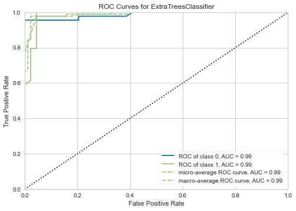

AUC - CatBoost Classifier

```
Chart 'AUC' for 'CatBoost Classifier' is unavailable !!!
```

AUC - Random Forest Classifier

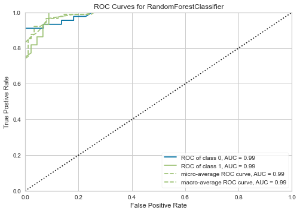

AUC - Gradient Boosting Classifier

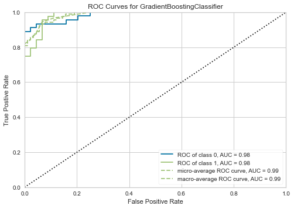

AUC - Ada Boost Classifier

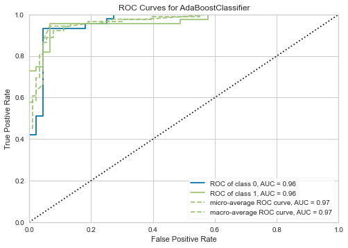

AUC - K Neighbors Classifier

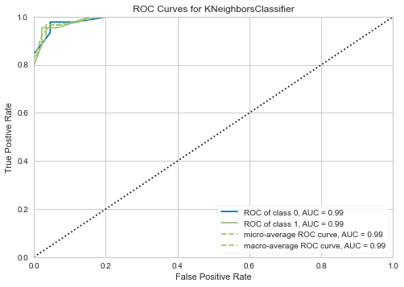

AUC - Light Gradient Boosting Machine

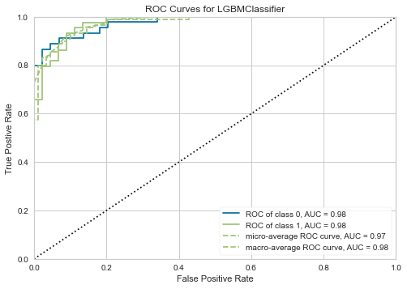

AUC - Extreme Gradient Boosting

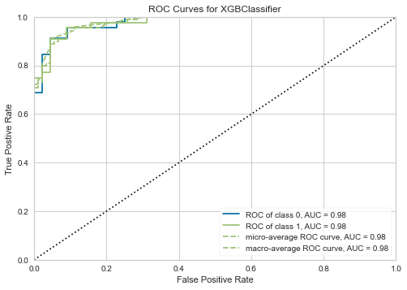

AUC - Decision Tree Classifier

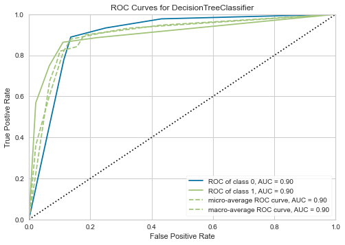

AUC - SVM - Radial Kernel

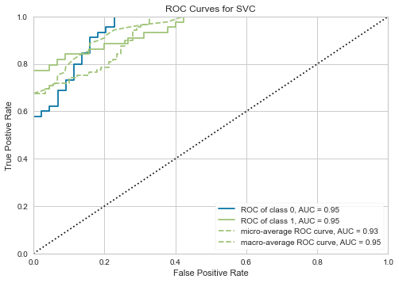

AUC - Logistic Regression

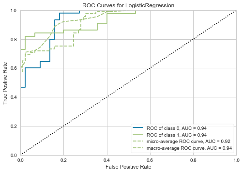

Confusion Matrix

Confusion Matrix - Extra Trees Classifier

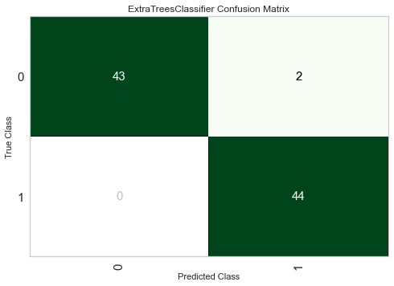

Confusion Matrix - CatBoost Classifier

```
Chart 'Confusion Matrix' for 'CatBoost Classifier' is unavailable !!!
```

Confusion Matrix - Random Forest Classifier

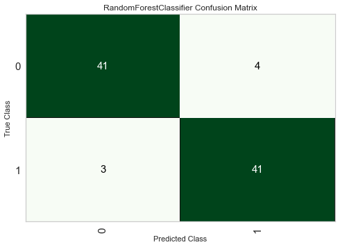

Confusion Matrix - Gradient Boosting Classifier

[42 more figures not shown]

```python
## Plot graphs for tuned model
# plot_list = [_ for _ in get_config('_available_plots').keys()]
plot_list = ['auc',
             'confusion_matrix',
             'pr',
             'error',
             'feature',
             'boundary']
display(Markdown("## Model Comparison by Charts"))
for plots in plot_list:
    display(Markdown(f"### {get_config('_available_plots')[plots]}"))
    plot_graphs_by_chart(plots,tuned_model_list)
```

#### Observations:

1. **MCC Score**: Extra Trees Classifier has the highest MCC score of 0.956followed by KNN of 0.9328.
2. **AUC** : Extra Trees, Random Forest,Gradient Boosting, K-Means Classifiers has the highest AUC of 0.99 .
3. **Confusion Matrix**: Extra Trees has ‘0’ false negative and low false positives. This is closely followed by KNN.
4. **PR Curve**: Random Forest and KNN have the highest Avg Precision score of 0.99.
5. **Prediction Error**: Extra Trees has no errors predicting ‘0’ and least error for predicting ‘1’ among all. This is again closely followed by KNN.
6. We will select *Extra Tree Classifier* as a model of choice and compare it's performance with other ensemble methods.

# Ensemble Methods

## 1) Ensemble Bagging

```python
# Bagging Method of Ensemble

ensemble_bagg_df = pd.DataFrame(columns=['Model','Accuracy', 'AUC', 'Recall', 'Prec.', 'F1', 'Kappa', 'MCC'])
for esti,algos in tqdm(final_model_list.items()):
    try:
        ensemble_model(algos,method='Bagging',n_estimators=10,optimize='MCC',verbose=False)
        mmetric = get_config('display_container')[-1].loc['Mean'].append(pd.Series({'Model':all_models_df.loc[esti]['Name']}))

    except:
        mmetric = pd.Series({'Model':all_models_df.loc[esti]['Name'],
                  'Accuracy':0.00,
                  'AUC':0.00,
                  'Recall':0.00,
                  'Prec.':0.00,
                  'F1':0.00,
                  'Kappa':0.00,
                  'MCC':0.00})
    ensemble_bagg_df = ensemble_bagg_df.append(mmetric,ignore_index=True)

ensemble_bagg_df
```

|  | Model | Accuracy | AUC | Recall | Prec. | F1 | Kappa | MCC |
| --- | --- | --- | --- | --- | --- | --- | --- | --- |
| 0 | Extra Trees Classifier | 0.9514 | 0.9895 | 0.9518 | 0.9548 | 0.9513 | 0.9029 | 0.9062 |
| 1 | CatBoost Classifier | 0.9414 | 0.9812 | 0.9418 | 0.9448 | 0.9413 | 0.8829 | 0.8861 |
| 2 | Random Forest Classifier | 0.9267 | 0.9761 | 0.9268 | 0.9286 | 0.9266 | 0.8533 | 0.8552 |
| 3 | Gradient Boosting Classifier | 0.9607 | 0.9815 | 0.9609 | 0.9642 | 0.9606 | 0.9214 | 0.9248 |
| 4 | Ada Boost Classifier | 0.9212 | 0.9676 | 0.9209 | 0.9251 | 0.9209 | 0.8422 | 0.8462 |
| 5 | K Neighbors Classifier | 0.9417 | 0.9845 | 0.9418 | 0.9481 | 0.9414 | 0.8832 | 0.8896 |
| 6 | Light Gradient Boosting Machine | 0.8969 | 0.9689 | 0.8968 | 0.9031 | 0.8963 | 0.7937 | 0.7999 |
| 7 | Extreme Gradient Boosting | 0.8969 | 0.9648 | 0.8968 | 0.9012 | 0.8966 | 0.7937 | 0.7980 |
| 8 | Decision Tree Classifier | 0.8871 | 0.9610 | 0.8873 | 0.8909 | 0.8867 | 0.7742 | 0.7779 |
| 9 | SVM - Radial Kernel | 0.8426 | 0.9457 | 0.8432 | 0.8484 | 0.8417 | 0.6857 | 0.6910 |
| 10 | Logistic Regression | 0.8231 | 0.9096 | 0.8232 | 0.8308 | 0.8213 | 0.6464 | 0.6538 |

## 2) Boosting

```python
# Boosting Method of Ensemble

ensemble_boost_df = pd.DataFrame(columns=['Model','Accuracy', 'AUC', 'Recall', 'Prec.', 'F1', 'Kappa', 'MCC'])
for esti,algos in tqdm(final_model_list.items()):
    try:
        ensemble_model(algos,method='Boosting',n_estimators=10,optimize='MCC',verbose=False)
        mmetric = get_config('display_container')[-1].loc['Mean'].append(pd.Series({'Model':all_models_df.loc[esti]['Name']}))

    except:
        mmetric = pd.Series({'Model':all_models_df.loc[esti]['Name'],
                  'Accuracy':0.00,
                  'AUC':0.00,
                  'Recall':0.00,
                  'Prec.':0.00,
                  'F1':0.00,
                  'Kappa':0.00,
                  'MCC':0.00})

    ensemble_boost_df = ensemble_boost_df.append(mmetric,ignore_index=True)

ensemble_boost_df
```

|  | Model | Accuracy | AUC | Recall | Prec. | F1 | Kappa | MCC |
| --- | --- | --- | --- | --- | --- | --- | --- | --- |
| 0 | Extra Trees Classifier | 0.9517 | 0.9911 | 0.9518 | 0.9541 | 0.9516 | 0.9032 | 0.9057 |
| 1 | CatBoost Classifier | 0.9312 | 0.9814 | 0.9309 | 0.9335 | 0.9311 | 0.8622 | 0.8646 |
| 2 | Random Forest Classifier | 0.9319 | 0.9810 | 0.9318 | 0.9361 | 0.9317 | 0.8637 | 0.8679 |
| 3 | Gradient Boosting Classifier | 0.9610 | 0.9865 | 0.9609 | 0.9635 | 0.9609 | 0.9218 | 0.9244 |
| 4 | Ada Boost Classifier | 0.9362 | 0.9670 | 0.9364 | 0.9390 | 0.9361 | 0.8724 | 0.8751 |
| 5 | K Neighbors Classifier | 0.0000 | 0.0000 | 0.0000 | 0.0000 | 0.0000 | 0.0000 | 0.0000 |
| 6 | Light Gradient Boosting Machine | 0.9017 | 0.9643 | 0.9018 | 0.9058 | 0.9012 | 0.8033 | 0.8074 |
| 7 | Extreme Gradient Boosting | 0.4881 | 0.5000 | 0.5000 | 0.2384 | 0.3203 | 0.0000 | 0.0000 |
| 8 | Decision Tree Classifier | 0.9362 | 0.9672 | 0.9359 | 0.9383 | 0.9361 | 0.8723 | 0.8744 |
| 9 | SVM - Radial Kernel | 0.7790 | 0.8943 | 0.7791 | 0.7869 | 0.7769 | 0.5579 | 0.5655 |
| 10 | Logistic Regression | 0.8081 | 0.9144 | 0.8082 | 0.8126 | 0.8071 | 0.6159 | 0.6204 |

## 3) Blending and Stacking

### 3.1) Shortlisting the Top 3 models for ensembling

```python
n_short_list = 3
short_list_models = final_score_df.sort_values(by='MCC',ascending=False)[:n_short_list]['Model'].values
top_models = [all_models_df[all_models_df['Name'] == algos].index.values[0] for algos in short_list_models ]
top_models_list = [final_model_list[keys] for keys in top_models]
top_models_list
```

```
[ExtraTreesClassifier(bootstrap=False, ccp_alpha=0.0, class_weight=None,
                      criterion='gini', max_depth=None, max_features='auto',
                      max_leaf_nodes=None, max_samples=None,
                      min_impurity_decrease=0.0, min_impurity_split=None,
                      min_samples_leaf=1, min_samples_split=2,
                      min_weight_fraction_leaf=0.0, n_estimators=100, n_jobs=-1,
                      oob_score=False, random_state=123, verbose=0,
                      warm_start=False),
 <catboost.core.CatBoostClassifier at 0x1332ea290>,
 RandomForestClassifier(bootstrap=True, ccp_alpha=0.0, class_weight=None,
                        criterion='gini', max_depth=None, max_features='auto',
                        max_leaf_nodes=None, max_samples=None,
                        min_impurity_decrease=0.0, min_impurity_split=None,
                        min_samples_leaf=1, min_samples_split=2,
                        min_weight_fraction_leaf=0.0, n_estimators=100,
                        n_jobs=-1, oob_score=False, random_state=123, verbose=0,
                        warm_start=False)]
```

### 3.2) Blending

```python
blended_df = pd.DataFrame(columns=['Accuracy', 'AUC', 'Recall', 'Prec.', 'F1', 'Kappa', 'MCC'])

try:
    blended_model = blend_models(top_models_list,
                                 optimize='MCC',
                                 method='soft',
                                 choose_better=True)
    mmetric = get_config('display_container')[-1].loc['Mean']
except:
    mmetric = pd.Series({'Meta Model':all_models_df.loc[esti]['Name'],
                  'Accuracy':0.00,
                  'AUC':0.00,
                  'Recall':0.00,
                  'Prec.':0.00,
                  'F1':0.00,
                  'Kappa':0.00,
                  'MCC':0.00})
blended_df = blended_df.append(mmetric,ignore_index=True)
display(blended_df)
```

|  | Accuracy | AUC | Recall | Prec. | F1 | Kappa | MCC |
| --- | --- | --- | --- | --- | --- | --- | --- |
| 0 | 1.0000 | 1.0000 | 1.0000 | 1.0000 | 1.0000 | 1.0000 | 1.0000 |
| 1 | 0.9524 | 1.0000 | 0.9500 | 0.9563 | 0.9522 | 0.9041 | 0.9083 |
| 2 | 0.9524 | 1.0000 | 0.9545 | 0.9567 | 0.9524 | 0.9050 | 0.9091 |
| 3 | 0.9048 | 0.9818 | 0.9045 | 0.9048 | 0.9048 | 0.8091 | 0.8091 |
| 4 | 1.0000 | 1.0000 | 1.0000 | 1.0000 | 1.0000 | 1.0000 | 1.0000 |
| 5 | 0.9500 | 1.0000 | 0.9500 | 0.9545 | 0.9499 | 0.9000 | 0.9045 |
| 6 | 0.9000 | 0.9900 | 0.9000 | 0.9167 | 0.8990 | 0.8000 | 0.8165 |
| 7 | 1.0000 | 1.0000 | 1.0000 | 1.0000 | 1.0000 | 1.0000 | 1.0000 |
| 8 | 0.9500 | 0.9900 | 0.9500 | 0.9545 | 0.9499 | 0.9000 | 0.9045 |
| 9 | 0.9500 | 1.0000 | 0.9500 | 0.9545 | 0.9499 | 0.9000 | 0.9045 |
| Mean | 0.9560 | 0.9962 | 0.9559 | 0.9598 | 0.9558 | 0.9118 | 0.9157 |
| SD | 0.0342 | 0.0062 | 0.0343 | 0.0314 | 0.0344 | 0.0685 | 0.0656 |

|  | Accuracy | AUC | Recall | Prec. | F1 | Kappa | MCC |
| --- | --- | --- | --- | --- | --- | --- | --- |
| 0 | 0.956 | 0.9962 | 0.9559 | 0.9598 | 0.9558 | 0.9118 | 0.9157 |

### 3.3) Stacking

```python
# Stacking Method of Ensemble

stacked_df = pd.DataFrame(columns=['Meta Model','Accuracy', 'AUC', 'Recall', 'Prec.', 'F1', 'Kappa', 'MCC'])
for esti,algos in tqdm(final_model_list.items()):
    try:
        stacked_model = stack_models(top_models_list,
                                     method='auto',
                                     optimize='MCC',
                                     meta_model=algos,
                                     choose_better=True,
                                     verbose=False)
        mmetric = get_config('display_container')[-1].loc['Mean'].append(pd.Series({'Meta Model':all_models_df.loc[esti]['Name']}))

    except:
        mmetric = pd.Series({'Meta Model':all_models_df.loc[esti]['Name'],
                  'Accuracy':0.00,
                  'AUC':0.00,
                  'Recall':0.00,
                  'Prec.':0.00,
                  'F1':0.00,
                  'Kappa':0.00,
                  'MCC':0.00})

    stacked_df = stacked_df.append(mmetric,ignore_index=True)

stacked_df
```

|  | Meta Model | Accuracy | AUC | Recall | Prec. | F1 | Kappa | MCC |
| --- | --- | --- | --- | --- | --- | --- | --- | --- |
| 0 | Extra Trees Classifier | 0.9464 | 0.9963 | 0.9468 | 0.9503 | 0.9463 | 0.8929 | 0.8966 |
| 1 | CatBoost Classifier | 0.9610 | 0.9981 | 0.9609 | 0.9636 | 0.9609 | 0.9218 | 0.9245 |
| 2 | Random Forest Classifier | 0.9562 | 0.9981 | 0.9559 | 0.9592 | 0.9561 | 0.9122 | 0.9153 |
| 3 | Gradient Boosting Classifier | 0.9660 | 0.9963 | 0.9659 | 0.9690 | 0.9659 | 0.9318 | 0.9348 |
| 4 | Ada Boost Classifier | 0.9752 | 0.9990 | 0.9750 | 0.9775 | 0.9752 | 0.9504 | 0.9526 |
| 5 | K Neighbors Classifier | 0.9512 | 0.9844 | 0.9509 | 0.9561 | 0.9509 | 0.9021 | 0.9071 |
| 6 | Light Gradient Boosting Machine | 0.9660 | 0.9991 | 0.9659 | 0.9681 | 0.9659 | 0.9318 | 0.9340 |
| 7 | Extreme Gradient Boosting | 0.9707 | 0.9972 | 0.9705 | 0.9733 | 0.9706 | 0.9413 | 0.9439 |
| 8 | Decision Tree Classifier | 0.9657 | 0.9872 | 0.9655 | 0.9688 | 0.9656 | 0.9313 | 0.9344 |
| 9 | SVM - Radial Kernel | 0.9607 | 0.9990 | 0.9605 | 0.9633 | 0.9606 | 0.9213 | 0.9239 |
| 10 | Logistic Regression | 0.9610 | 0.9971 | 0.9605 | 0.9651 | 0.9607 | 0.9216 | 0.9258 |

```python
display(Markdown("## <center>Model Scoring and Comparison</center>"))

display(predict_tuned_df.style.bar(subset=['Accuracy', 'AUC', 'Recall', 'Prec.', 'F1', 'Kappa', 'MCC'],
                         color=['#99ffff']).\
set_caption("(1) Train/Test Scores - Discrete Models").\
set_table_attributes("style='display:inline; font-size:80%' ").\
set_table_styles(styles))

display(ensemble_bagg_df.style.bar(subset=['Accuracy', 'AUC', 'Recall', 'Prec.', 'F1', 'Kappa', 'MCC'],
                         color=['#99ffff']).\
set_caption("(2) Score - Ensemble Bagging").\
set_table_attributes("style='display:inline; font-size:80%' ").\
set_table_styles(styles))

display(ensemble_boost_df.style.bar(subset=['Accuracy', 'AUC', 'Recall', 'Prec.', 'F1', 'Kappa', 'MCC'],
                         color=['#99ffff']).\
set_caption("(3) Score - Ensemble Boosting").\
set_table_attributes("style='display:inline; font-size:80%' ").\
set_table_styles(styles))

display(blended_df.style.bar(subset=['Accuracy', 'AUC', 'Recall', 'Prec.', 'F1', 'Kappa', 'MCC'],
                         color=['#99ffff']).\
set_caption("(4) Score - Ensemble Blending").\
set_table_attributes("style='display:inline; font-size:80%' ").\
set_table_styles(styles))


display(stacked_df.style.bar(subset=['Accuracy', 'AUC', 'Recall', 'Prec.', 'F1', 'Kappa', 'MCC'],
                         color=['#99ffff']).\
set_caption("(5) Score - Ensemble Stacking").\
set_table_attributes("style='display:inline; font-size:80%' ").\
set_table_styles(styles))
```

Model Scoring and Comparison

(1) Train/Test Scores - Discrete Models

|  | Model | Accuracy | AUC | Recall | Prec. | F1 | Kappa | MCC |
| --- | --- | --- | --- | --- | --- | --- | --- | --- |
| 0 | Extra Trees Classifier | 0.977500 | 0.986600 | 0.977800 | 0.978500 | 0.977500 | 0.955100 | 0.956000 |
| 1 | CatBoost Classifier | 0.921300 | 0.984300 | 0.921200 | 0.921500 | 0.921300 | 0.842600 | 0.842900 |
| 2 | Random Forest Classifier | 0.921300 | 0.986100 | 0.921500 | 0.921600 | 0.921300 | 0.842700 | 0.842900 |
| 3 | Gradient Boosting Classifier | 0.932600 | 0.984800 | 0.932600 | 0.932600 | 0.932600 | 0.865200 | 0.865200 |
| 4 | Ada Boost Classifier | 0.921300 | 0.963100 | 0.921200 | 0.921500 | 0.921300 | 0.842600 | 0.842900 |
| 5 | K Neighbors Classifier | 0.966300 | 0.992400 | 0.966200 | 0.966500 | 0.966300 | 0.932600 | 0.932800 |
| 6 | Light Gradient Boosting Machine | 0.910100 | 0.976800 | 0.910100 | 0.910100 | 0.910100 | 0.820200 | 0.820200 |
| 7 | Extreme Gradient Boosting | 0.910100 | 0.978800 | 0.910100 | 0.910100 | 0.910100 | 0.820200 | 0.820200 |
| 8 | Decision Tree Classifier | 0.842700 | 0.902300 | 0.841700 | 0.853900 | 0.841300 | 0.684700 | 0.696100 |
| 9 | SVM - Radial Kernel | 0.786500 | 0.947000 | 0.788100 | 0.813800 | 0.782200 | 0.574400 | 0.600400 |
| 10 | Logistic Regression | 0.752800 | 0.936400 | 0.754000 | 0.766800 | 0.750000 | 0.506800 | 0.520000 |

(2) Score - Ensemble Bagging

|  | Model | Accuracy | AUC | Recall | Prec. | F1 | Kappa | MCC |
| --- | --- | --- | --- | --- | --- | --- | --- | --- |
| 0 | Extra Trees Classifier | 0.951400 | 0.989500 | 0.951800 | 0.954800 | 0.951300 | 0.902900 | 0.906200 |
| 1 | CatBoost Classifier | 0.941400 | 0.981200 | 0.941800 | 0.944800 | 0.941300 | 0.882900 | 0.886100 |
| 2 | Random Forest Classifier | 0.926700 | 0.976100 | 0.926800 | 0.928600 | 0.926600 | 0.853300 | 0.855200 |
| 3 | Gradient Boosting Classifier | 0.960700 | 0.981500 | 0.960900 | 0.964200 | 0.960600 | 0.921400 | 0.924800 |
| 4 | Ada Boost Classifier | 0.921200 | 0.967600 | 0.920900 | 0.925100 | 0.920900 | 0.842200 | 0.846200 |
| 5 | K Neighbors Classifier | 0.941700 | 0.984500 | 0.941800 | 0.948100 | 0.941400 | 0.883200 | 0.889600 |
| 6 | Light Gradient Boosting Machine | 0.896900 | 0.968900 | 0.896800 | 0.903100 | 0.896300 | 0.793700 | 0.799900 |
| 7 | Extreme Gradient Boosting | 0.896900 | 0.964800 | 0.896800 | 0.901200 | 0.896600 | 0.793700 | 0.798000 |
| 8 | Decision Tree Classifier | 0.887100 | 0.961000 | 0.887300 | 0.890900 | 0.886700 | 0.774200 | 0.777900 |
| 9 | SVM - Radial Kernel | 0.842600 | 0.945700 | 0.843200 | 0.848400 | 0.841700 | 0.685700 | 0.691000 |
| 10 | Logistic Regression | 0.823100 | 0.909600 | 0.823200 | 0.830800 | 0.821300 | 0.646400 | 0.653800 |

(3) Score - Ensemble Boosting

|  | Model | Accuracy | AUC | Recall | Prec. | F1 | Kappa | MCC |
| --- | --- | --- | --- | --- | --- | --- | --- | --- |
| 0 | Extra Trees Classifier | 0.951700 | 0.991100 | 0.951800 | 0.954100 | 0.951600 | 0.903200 | 0.905700 |
| 1 | CatBoost Classifier | 0.931200 | 0.981400 | 0.930900 | 0.933500 | 0.931100 | 0.862200 | 0.864600 |
| 2 | Random Forest Classifier | 0.931900 | 0.981000 | 0.931800 | 0.936100 | 0.931700 | 0.863700 | 0.867900 |
| 3 | Gradient Boosting Classifier | 0.961000 | 0.986500 | 0.960900 | 0.963500 | 0.960900 | 0.921800 | 0.924400 |
| 4 | Ada Boost Classifier | 0.936200 | 0.967000 | 0.936400 | 0.939000 | 0.936100 | 0.872400 | 0.875100 |
| 5 | K Neighbors Classifier | 0.000000 | 0.000000 | 0.000000 | 0.000000 | 0.000000 | 0.000000 | 0.000000 |
| 6 | Light Gradient Boosting Machine | 0.901700 | 0.964300 | 0.901800 | 0.905800 | 0.901200 | 0.803300 | 0.807400 |
| 7 | Extreme Gradient Boosting | 0.488100 | 0.500000 | 0.500000 | 0.238400 | 0.320300 | 0.000000 | 0.000000 |
| 8 | Decision Tree Classifier | 0.936200 | 0.967200 | 0.935900 | 0.938300 | 0.936100 | 0.872300 | 0.874400 |
| 9 | SVM - Radial Kernel | 0.779000 | 0.894300 | 0.779100 | 0.786900 | 0.776900 | 0.557900 | 0.565500 |
| 10 | Logistic Regression | 0.808100 | 0.914400 | 0.808200 | 0.812600 | 0.807100 | 0.615900 | 0.620400 |

(4) Score - Ensemble Blending

|  | Accuracy | AUC | Recall | Prec. | F1 | Kappa | MCC |
| --- | --- | --- | --- | --- | --- | --- | --- |
| 0 | 0.956000 | 0.996200 | 0.955900 | 0.959800 | 0.955800 | 0.911800 | 0.915700 |

(5) Score - Ensemble Stacking

|  | Meta Model | Accuracy | AUC | Recall | Prec. | F1 | Kappa | MCC |
| --- | --- | --- | --- | --- | --- | --- | --- | --- |
| 0 | Extra Trees Classifier | 0.946400 | 0.996300 | 0.946800 | 0.950300 | 0.946300 | 0.892900 | 0.896600 |
| 1 | CatBoost Classifier | 0.961000 | 0.998100 | 0.960900 | 0.963600 | 0.960900 | 0.921800 | 0.924500 |
| 2 | Random Forest Classifier | 0.956200 | 0.998100 | 0.955900 | 0.959200 | 0.956100 | 0.912200 | 0.915300 |
| 3 | Gradient Boosting Classifier | 0.966000 | 0.996300 | 0.965900 | 0.969000 | 0.965900 | 0.931800 | 0.934800 |
| 4 | Ada Boost Classifier | 0.975200 | 0.999000 | 0.975000 | 0.977500 | 0.975200 | 0.950400 | 0.952600 |
| 5 | K Neighbors Classifier | 0.951200 | 0.984400 | 0.950900 | 0.956100 | 0.950900 | 0.902100 | 0.907100 |
| 6 | Light Gradient Boosting Machine | 0.966000 | 0.999100 | 0.965900 | 0.968100 | 0.965900 | 0.931800 | 0.934000 |
| 7 | Extreme Gradient Boosting | 0.970700 | 0.997200 | 0.970500 | 0.973300 | 0.970600 | 0.941300 | 0.943900 |
| 8 | Decision Tree Classifier | 0.965700 | 0.987200 | 0.965500 | 0.968800 | 0.965600 | 0.931300 | 0.934400 |
| 9 | SVM - Radial Kernel | 0.960700 | 0.999000 | 0.960500 | 0.963300 | 0.960600 | 0.921300 | 0.923900 |
| 10 | Logistic Regression | 0.961000 | 0.997100 | 0.960500 | 0.965100 | 0.960700 | 0.921600 | 0.925800 |

### Summary and Conslusion

#### Summary

1. Pycaret version 2.2 has been used for ML modelling and modelling phases has been automated to train,test,validate and score all models
2. MCC has been used as a performance measure due to it;s stability against imbalanced data. Also, MCC igenerates a high score only if the binary predictor was able to correctly predict the majority of positive data instances and the majority of negative data instances.
3. 11 discrete models have been trained and tested.
4. Ensemble techniques such as Bagging and Boosting has been evaluated for all 11 models.
5. The top 3 perdforming discrete models have been picked from the final models and the same is used in blending and stacking.
6. Finally performance score is compared across all 5 cases and a model with the highest MCC score adn AUC as a tie breaker has been used in slecting the model. #### Model Comparison based on MCC as a performance measure
7. Discrete Model : Extra Trees with 0.956
8. Ensemble Bagging: Gradient Boosting with 0.9248
9. Ensemble Boosting: Gradient Boosting with 0.9244
10. Ensemble Blending: 0.9157
11. Ensemble Stacking: 0.9526 with Ada Boost as a Meta Classifier
12. Comparing models with highest MCC as a performance score, i.,e *Extra Trees and Stacking*, AUC is higher for Stacking.
13. *Ensemble Stacking is the model of choice.*